# L1P1 - Em grupo

Erick, Rafael e João

# 1. Perguntas

A seguir, serão apresentadas e respondidas 3 perguntas a respeito do clima de Campina Grande e João Pessoa. 2 sobre a temperatura e 1 sobre a incidência de chuvas.

#### 1.1 Qual foi o São João mais frio de Campina Grande?

Nosso objetivo é descobrir em qual ano houve o São João mais frio de nossa cidade, para isso iremos obter as temperaturas médias semanais de todo o mês de junho, mas por qual motivo usar as médias? Porque elas nos dão uma ideia de onde está a concentração das temperaturas levantadas em cada uma das semanas.

Nossa visualização mostra um gráfico de linha da média das temperaturas do mês de junho, de 1995 a 2018, assim como um gráfico de pontos que retrata as temperaturas médias semanais em cada um desses meses.

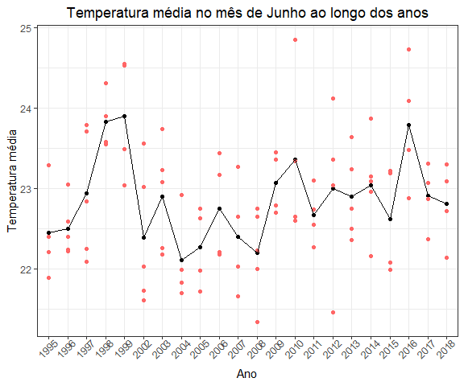

```r
junhoCG <- climas %>%
    group_by(ano) %>%
    filter(mes == 6 & cidade == "Campina Grande") %>%
    mutate(media = round(mean(tmedia), 2))

junhoCG$ano <- as.factor(junhoCG$ano)

ggplot(junhoCG, aes(x = ano, y = media, group = 1)) +
        geom_point() +
        geom_point(aes(y=tmedia), color = "#FF6666") +
        geom_line() +
        labs(y = "Temperatura média", x = "Ano") +
        ggtitle("Temperatura média no mês de Junho ao longo dos anos") +
        theme(plot.title = element_text(hjust = 0.5), axis.text.x = element_text(hjust = 0.8, angle = 45))
```

Observando o gráfico, podemos notar que o São João mais frio de Campina Grande foi em 2004, porém a semana mais fria que tivemos em um período junino aconteceu apenas em 2008. Porque tal ano não foi o mais frio então? Observando as médias semanais de 2008 podemos ver que, apesar de ter tido a semana mais fria de Junho, seus dados estão concentrados mais acima de 22°C, fazendo com que sua média fique maior que a do ano 2004.

#### 1.2 No geral, onde chove mais?

Visualizando o gráfico que mostra o volume médio de chuva entre CG e JP podemos notar que a volume médio de chuvas em JP é mais do que duas vezes maior do que o volume médio de chuvas em CG. Utilizando apenas desse gráfico podemos constatar que durante o período de 1995 e 2019 JP pode ser considerada a cidade que chove mais em comparação com CG.

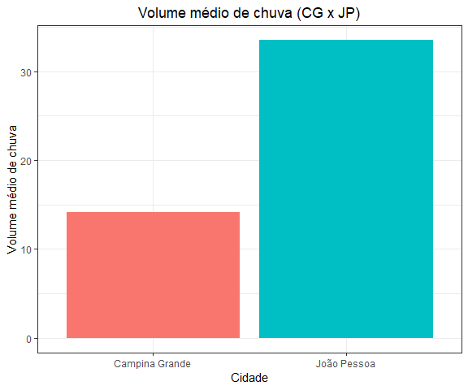

```r
chuvas <- climas %>%
    group_by(cidade) %>%
    filter(ano > 1994 & !(ano %in% c(2000, 2001))) %>%
    summarise(media = round(mean(chuva), 2))

ggplot(chuvas, aes(x=cidade, y=media, fill = cidade)) +
        geom_bar(stat = "identity", show.legend = FALSE) +
        labs(y = "Volume médio de chuva", x = "Cidade") +
        ggtitle("Volume médio de chuva (CG x JP)") +
        theme(plot.title = element_text(hjust = 0.5))
```

Visualizando o boxplot da quantidade de chuva semanal de cada cidade podemos notar uma quantidade considerada de valores discrepantes. Tais valores podem fazer a medida agregadora da média se tornar enviesada, portanto houve também a necessidade de utilizarmos a mediana como medida agregadora para suporte a resposta da pergunta proposta.

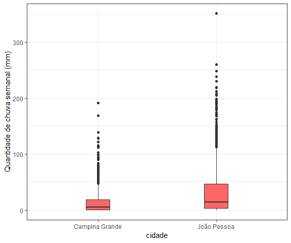

```r
climas %>%
    filter(ano > 1994 & !(ano %in% c(2000, 2001))) %>%
    ggplot(aes(x = cidade, y = chuva)) +
    geom_boxplot(width = .2, fill = "#FF6666") +
    ylab("Quantidade de chuva semanal (mm)")
```

#### 1.3 Qual o verão mais quente?

O objetivo é tomar conhecimento sobre em qual ano tivemos o verão mais quente. Essa resposta pode nos ajudar a responder várias outras possíveis perguntas. Será que algum ano específico se destacou muito em relação aos outros? O ano do verão mais quente é o mesmo para as duas cidades? Os anos mais recentes são os mais quentes? Para responder a pergunta é necessário obter as temperaturas médias semanais das duas cidades no meses de janeiro, fevereiro e março e verificar os valores por ano com o objetivo de terminar em que qual ano tivemos temperaturas mais elevadas.

As duas primeiras visualizações mostram gráficos de barras para as duas cidades contendo a média das temperaturas médias semanais por ano. A terceira visualização mostra a distribuição das temperaturas médias por ano e por cidade.

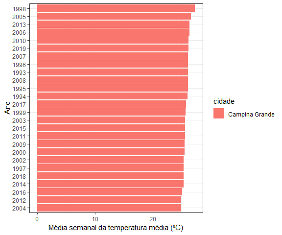

```r
verao_cg <- climas %>%
    filter(cidade == "Campina Grande" & mes %in% c(1, 2, 3) & ano > 1992 & ano != 2001) %>%
    group_by(ano) %>%
    mutate(media = round(mean(tmedia), 2))

verao_jp <- climas %>%
    filter(cidade == "João Pessoa" & mes %in% c(1, 2, 3) & ano > 1992 & ano != 2001) %>%
    group_by(ano) %>%
    mutate(media = round(mean(tmedia), 2))

verao_cg$ano <- as.factor(verao_cg$ano)
verao_jp$ano <- as.factor(verao_jp$ano)

ggplot(data = verao_cg, aes(reorder(ano,media), y = media, fill = cidade)) +
    geom_bar(stat = "identity", position = "dodge") +
    ylab("Média semanal da temperatura média (ºC)") +
    xlab("Ano") +
    coord_flip()
```

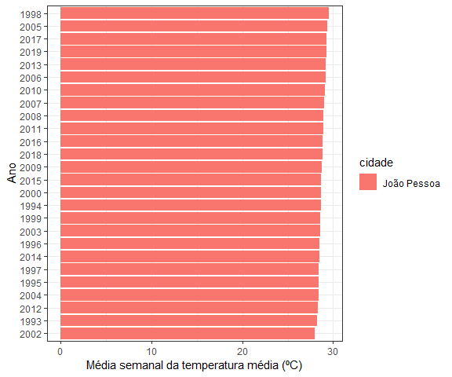

```r
ggplot(data = verao_jp, aes(reorder(ano,media), y = media, fill = cidade)) +
    geom_bar(stat = "identity", position = "dodge") +
    ylab("Média semanal da temperatura média (ºC)") +
    xlab("Ano") +
    coord_flip()
```

A diferença da média das temperaturas é pequena de ano para ano, mas o ano de 1998 apresentou maior média para ambas as cidades. O ano de 2005 vem logo em seguida também para as duas cidades.

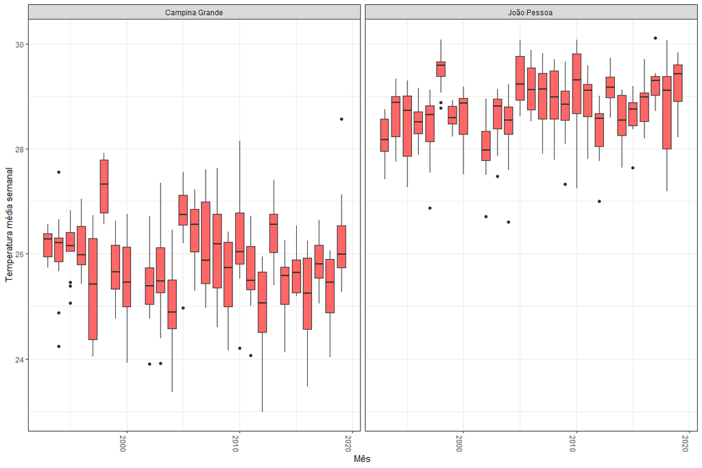

```r
verao <- climas %>%
    group_by(ano, cidade) %>%
    filter(mes %in% c(1, 2, 3) & ano > 1992 & ano != 2001) %>%
    mutate(media = round(mean(tmedia), 2))

ggplot(verao, aes(x = ano, y = tmedia, group = ano)) +
       geom_boxplot(fill = "#FF6666") +
       xlab("Mês") +
       ylab("Temperatura média semanal") +
       facet_grid(.~cidade) +
       theme(axis.text.x = element_text(angle = 270))
```

Observando a distribuição dos dados com boxplots, vemos que para Campina Grande está mais claro que 1998 foi o ano com o verão mais quente, mas para João Pessoa isso não fica tão claro assim, já que vários anos aparecem “empatados” a olho nu.